# Human genomics: The past, present and future of the human genome

## Ploting our fake data

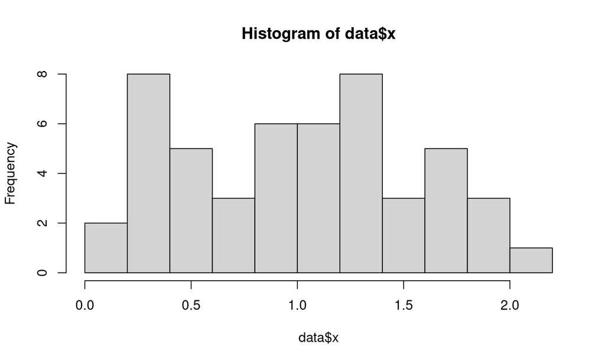

```r
hist(data$x)
```

## Ploting our fake data

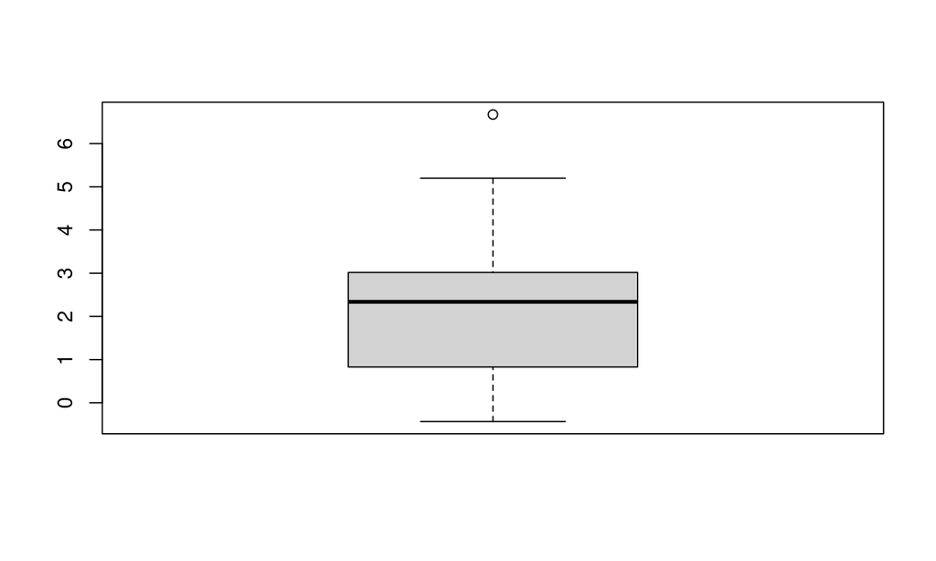

```r
boxplot(data$y)
```

## Ploting our fake data

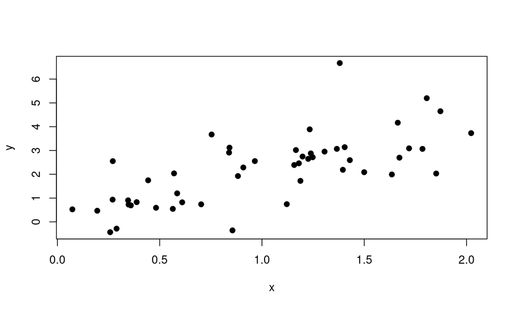

```r
plot(y ~ x, pch = 19)
```

## Ploting our fake data

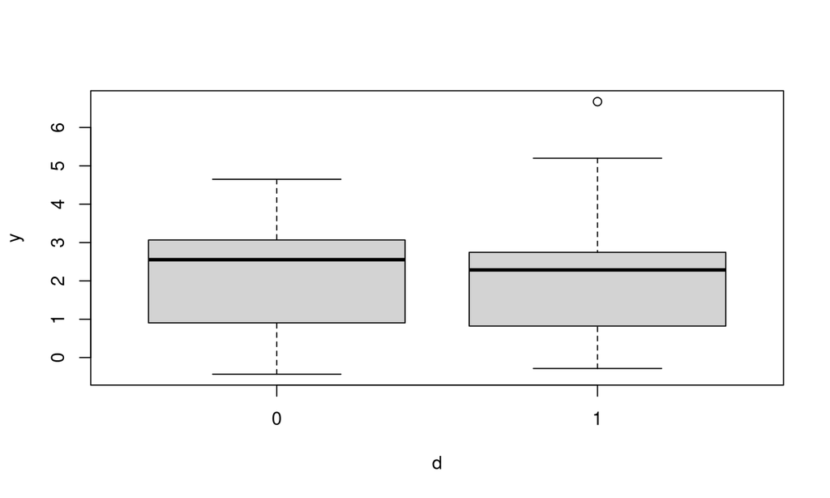

```r
boxplot(y ~ d, data)
```

## Ploting our fake data

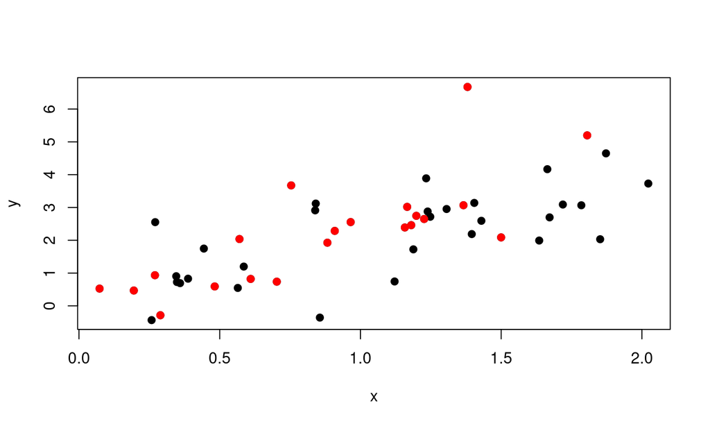

```r
plot(y ~ x, pch = 19)
points(y[d==1] ~ x[d==1], col = "red", pch = 19)
```

## Fitting a linear model

Fitting a linear model means finding values a and b such that the values of y are aproximated by: \[ y_i = a + bx_i \]

```r
lm_xy = lm(y ~ x)
lm_xy
```

```
##
## Call:
## lm(formula = y ~ x)
##
## Coefficients:
## (Intercept)            x
##      0.2693       1.8941
```

## Ploting the fit

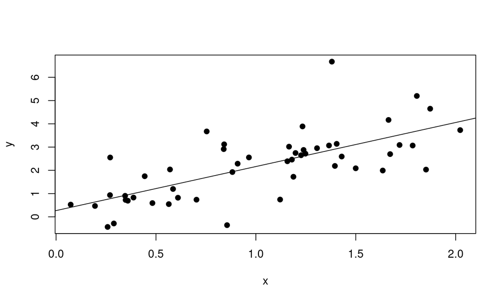

```r
plot(y ~ x, pch = 19)
abline(lm_xy)
```

## Ploting the fit

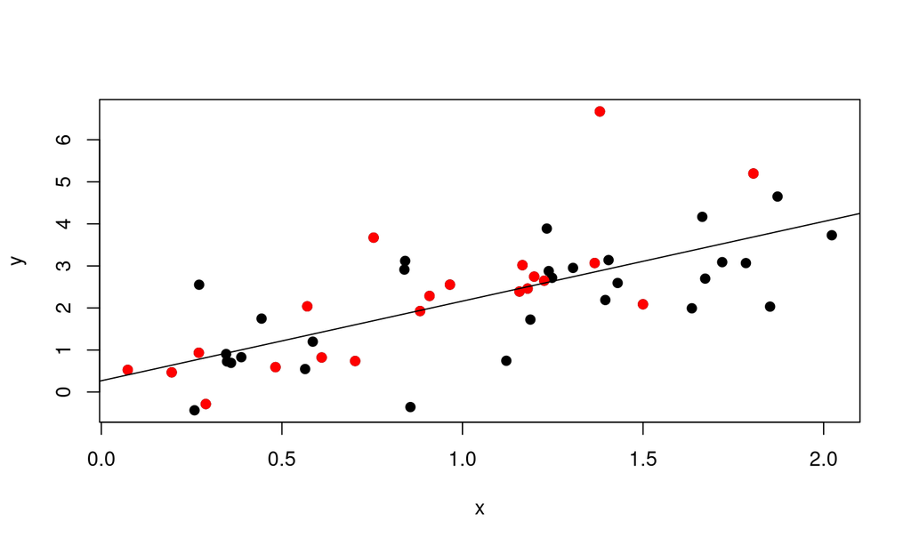

```r
plot(y ~ x, pch = 19)
points(y[d==1] ~ x[d==1], col = "red", pch = 19)
abline(a = coef(lm_xy)[1],
       b = coef(lm_xy)[2])
```

## Didn’t we have a categorical variable?

Yes we did. Let’s include it:

```r
lm_xdy = lm(y ~ x + d)
lm_xdy
```

```
##
## Call:
## lm(formula = y ~ x + d)
##
## Coefficients:
## (Intercept)            x            d
##    -0.01624      1.98066      0.47135
```

## Plotting the new model

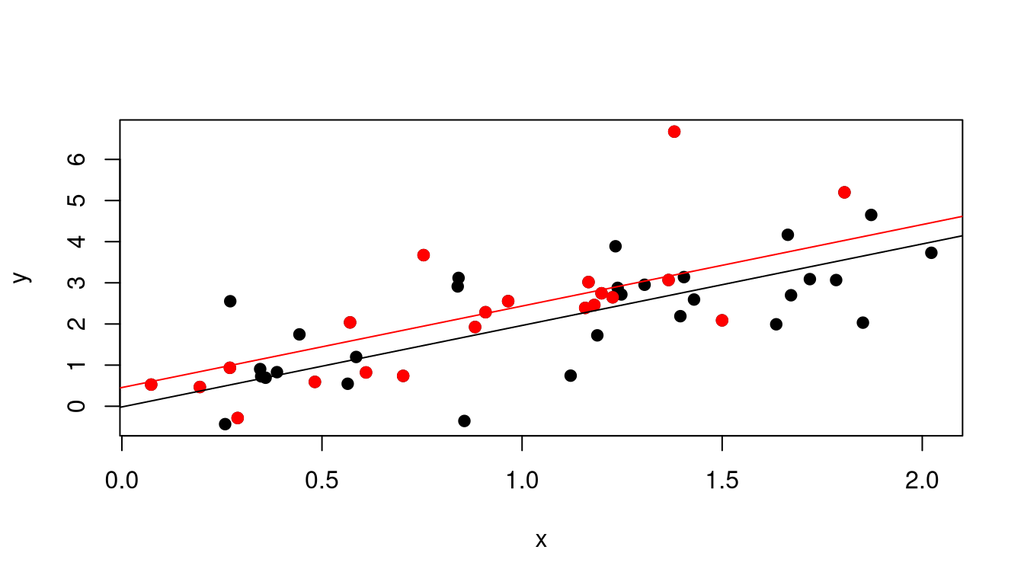

```r
plot(y ~ x, pch = 19)
points(y[d==1] ~ x[d==1], col = "red", pch = 19)
abline(a = coef(lm_xdy)[1], b = coef(lm_xdy)[2])
abline(a = coef(lm_xdy)[1] + coef(lm_xdy)[3],
       b = coef(lm_xdy)[2], col = "red")
```

## Very typical use case of linear regression in genetics

The question we are asking is:

- Is there a difference in the mean between two groups after accounting for a continuous confounder?

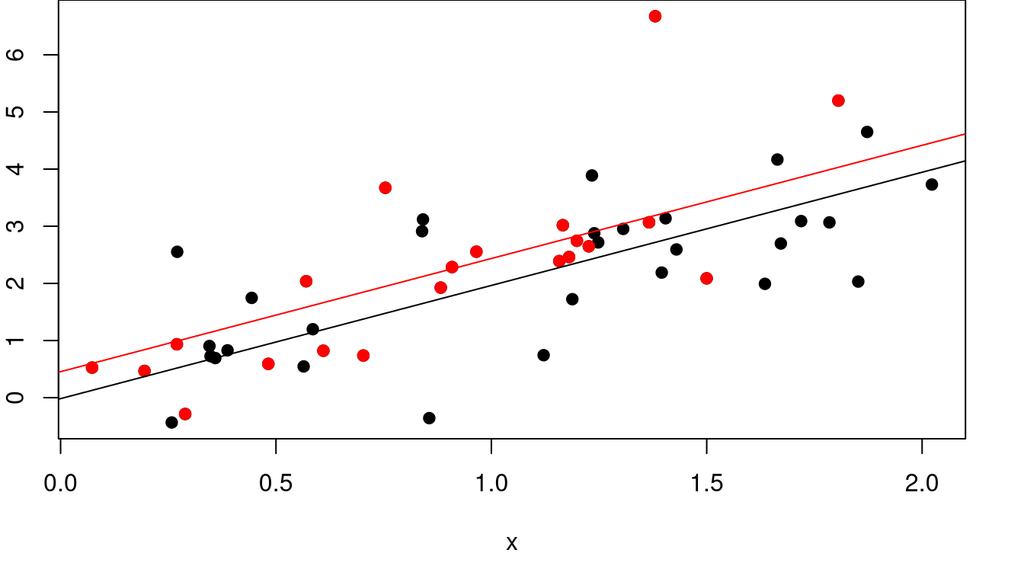

## What are p-values?

- P-values is the probability of observing the data you observed under some (null) model.
- In the olden-times this meant using simplified models and analytic calculations to figure out the p-value.
- Now we just use computers to figure out any p-value we like.
- What it is not:
- The probability the observed effect is not real
- The probability the null model is correct
- A measure of the real world importance of the observed effect

## Getting P-values in R

```r
summary(lm_xdy)
```

```
##
## Call:
## lm(formula = y ~ x + d)
##
## Residuals:
##     Min      1Q  Median      3Q     Max
## -2.0366 -0.5578 -0.0785  0.3801  3.4853
##
## Coefficients:
##             Estimate Std. Error t value Pr(>|t|)
## (Intercept) -0.01624    0.36305  -0.045    0.965
## x            1.98066    0.28090   7.051 6.84e-09 ***
## d            0.47135    0.30026   1.570    0.123
## ---
## Signif. codes:  0 '***' 0.001 '**' 0.01 '*' 0.05 '.' 0.1 ' ' 1
##
## Residual standard error: 1.028 on 47 degrees of freedom
## Multiple R-squared:  0.5142, Adjusted R-squared:  0.4936
## F-statistic: 24.88 on 2 and 47 DF,  p-value: 4.276e-08
```

## Effect size and significance

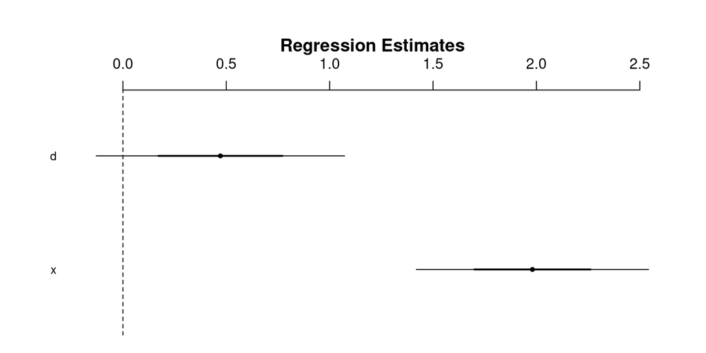

```r
suppressPackageStartupMessages(library(arm))
coefplot(lm_xdy)
```